# Project: Movie Data Analysis

- Introduction
- Data Wrangling
- Exploratory Data Analysis
- Conclusions

## Introduction

### Dataset Description

> This project involves the data analysis for movies shows. The dataset source is from "The Movie Database (TMDB)". The dataset comprises of about 10866 rows and 21 columns. The key features include the director of each movie, keywords, runtime, genres, production companies, release year, taglin, overview, vote count, vote average, release year, budget and revenue. We will be interested in finding an insight on the kind of movie that attract viewer which makes them to give high rating. We will also also check for the kinds of attributes viewer check in the movie which return high revenue to the movie industry.

### Questions for our Analysis

> In our investigation, we will answer the following questions:
> - What kind of movie genres yield the highest profit?
> - What characteristics are linked to the popularity of the movies?
> - Which director is the most well-known and makes the most money from his films?

To begin with, we will import libraries for loading our dataset and visualization tools.

```python
# Import libraries
import pandas as pd
import numpy as np
import matplotlib.pyplot as plt
import seaborn as sn

# visualization display properly in the jupyter notebook
%matplotlib inline
```

## Data Wrangling

> We'll examine our data in this section, assess its quality, clean it up, and make it available in a high-quality format that will be ready for analysis.

### General Properties

```python
# load the dataset
df = pd.read_csv("tmdb-movies.csv")

# check the first 5 rows of the dataset
df.head()
```

|  | id | imdb_id | popularity | budget | revenue | original_title | cast | homepage | director | tagline | ... | overview | runtime | genres | production_companies | release_date | vote_count | vote_average | release_year | budget_adj | revenue_adj |
| --- | --- | --- | --- | --- | --- | --- | --- | --- | --- | --- | --- | --- | --- | --- | --- | --- | --- | --- | --- | --- | --- |
| 0 | 135397 | tt0369610 | 32.985763 | 150000000 | 1513528810 | Jurassic World | Chris Pratt\|Bryce Dallas Howard\|Irrfan Khan\|Vi... | http://www.jurassicworld.com/ | Colin Trevorrow | The park is open. | ... | Twenty-two years after the events of Jurassic ... | 124 | Action\|Adventure\|Science Fiction\|Thriller | Universal Studios\|Amblin Entertainment\|Legenda... | 6/9/15 | 5562 | 6.5 | 2015 | 1.379999e+08 | 1.392446e+09 |
| 1 | 76341 | tt1392190 | 28.419936 | 150000000 | 378436354 | Mad Max: Fury Road | Tom Hardy\|Charlize Theron\|Hugh Keays-Byrne\|Nic... | http://www.madmaxmovie.com/ | George Miller | What a Lovely Day. | ... | An apocalyptic story set in the furthest reach... | 120 | Action\|Adventure\|Science Fiction\|Thriller | Village Roadshow Pictures\|Kennedy Miller Produ... | 5/13/15 | 6185 | 7.1 | 2015 | 1.379999e+08 | 3.481613e+08 |
| 2 | 262500 | tt2908446 | 13.112507 | 110000000 | 295238201 | Insurgent | Shailene Woodley\|Theo James\|Kate Winslet\|Ansel... | http://www.thedivergentseries.movie/#insurgent | Robert Schwentke | One Choice Can Destroy You | ... | Beatrice Prior must confront her inner demons ... | 119 | Adventure\|Science Fiction\|Thriller | Summit Entertainment\|Mandeville Films\|Red Wago... | 3/18/15 | 2480 | 6.3 | 2015 | 1.012000e+08 | 2.716190e+08 |
| 3 | 140607 | tt2488496 | 11.173104 | 200000000 | 2068178225 | Star Wars: The Force Awakens | Harrison Ford\|Mark Hamill\|Carrie Fisher\|Adam D... | http://www.starwars.com/films/star-wars-episod... | J.J. Abrams | Every generation has a story. | ... | Thirty years after defeating the Galactic Empi... | 136 | Action\|Adventure\|Science Fiction\|Fantasy | Lucasfilm\|Truenorth Productions\|Bad Robot | 12/15/15 | 5292 | 7.5 | 2015 | 1.839999e+08 | 1.902723e+09 |
| 4 | 168259 | tt2820852 | 9.335014 | 190000000 | 1506249360 | Furious 7 | Vin Diesel\|Paul Walker\|Jason Statham\|Michelle ... | http://www.furious7.com/ | James Wan | Vengeance Hits Home | ... | Deckard Shaw seeks revenge against Dominic Tor... | 137 | Action\|Crime\|Thriller | Universal Pictures\|Original Film\|Media Rights ... | 4/1/15 | 2947 | 7.3 | 2015 | 1.747999e+08 | 1.385749e+09 |

5 rows × 21 columns

We can see that the column cast and genre contain mulltiple values separated by pipe (|), we can going to separate the genre column in our cleaning process because it will be useful in our analysis. We will drop the id column because it has no significant in our analysis.

```python
# check for rows and columns

df.shape
```

```
(10866, 21)
```

The dataset contains 10866 rows and 21 columns. Each row of the dataset contains information about one movie.

Let's check the data type for each column.

```python
df.dtypes
```

```
id                        int64
imdb_id                  object
popularity              float64
budget                    int64
revenue                   int64
original_title           object
cast                     object
homepage                 object
director                 object
tagline                  object
keywords                 object
overview                 object
runtime                   int64
genres                   object
production_companies     object
release_date             object
vote_count                int64
vote_average            float64
release_year              int64
budget_adj              float64
revenue_adj             float64
dtype: object
```

It looks like our columns are in proper data type except the release year which should be a date time and not an integer. However, it's also interesting to find the kind of object type for the release date. So, let check that out

```python
type(df['release_date'][0])
```

```
str
```

Interestingly, we have found out that release date is a string data type. We need to convert it to a datatime data type. his will be done in the data cleaning section.

```python
# Display a concise summary of the dataframe
# including the non-null values in each column

df.info()
```

```
<class 'pandas.core.frame.DataFrame'>
RangeIndex: 10866 entries, 0 to 10865
Data columns (total 21 columns):
id                      10866 non-null int64
imdb_id                 10856 non-null object
popularity              10866 non-null float64
budget                  10866 non-null int64
revenue                 10866 non-null int64
original_title          10866 non-null object
cast                    10790 non-null object
homepage                2936 non-null object
director                10822 non-null object
tagline                 8042 non-null object
keywords                9373 non-null object
overview                10862 non-null object
runtime                 10866 non-null int64
genres                  10843 non-null object
production_companies    9836 non-null object
release_date            10866 non-null object
vote_count              10866 non-null int64
vote_average            10866 non-null float64
release_year            10866 non-null int64
budget_adj              10866 non-null float64
revenue_adj             10866 non-null float64
dtypes: float64(4), int64(6), object(11)
memory usage: 1.7+ MB
```

- cast
- homepage
- director
- tagline
- keywords
- overview
- genres
- production companies

Let's check the percentage of the misssing missing values to see if we can drop them or not in our data analysis.

```python
# percentage of missing value function

def missing_percent(column_name):
    '''function to check the percent of missing values in the columns
        store the column name and get the count of the missing values
        in the column and divide by total number of rows
    '''

    column_name = sum(df[column_name].isnull())/len(df)*100
    return  round(column_name, 2)
```

```python
# percent missing value for homepage
print('homepage: ' + str(missing_percent('homepage'))+ '%')

# percent missing value for cast
print('cast: ' + str(missing_percent('cast')) + '%')

# percent missing value for director
print('director: ' + str(missing_percent('director')) + '%')

# percent missing value for tagline
print('tagline: ' + str(missing_percent('tagline')) + '%')

# percent missing value for keywords
print('keywords: ' + str(missing_percent('keywords')) + '%')

# percent missing value for overview
print('overview: ' + str(missing_percent('overview')) + '%')

# percent missing value for genres
print('genres: ' + str(missing_percent('genres')) + '%')

# percent missing value for production company
print('production_companies: ' + str(missing_percent('production_companies')) + '%')
```

```
homepage: 72.98%
cast: 0.7%
director: 0.4%
tagline: 25.99%
keywords: 13.74%
overview: 0.04%
genres: 0.21%
production_companies: 9.48%
```

From this result, we can see that:

```python
# Checking for unique values in each column

df.nunique()
```

```
id                      10865
imdb_id                 10855
popularity              10814
budget                    557
revenue                  4702
original_title          10571
cast                    10719
homepage                 2896
director                 5067
tagline                  7997
keywords                 8804
overview                10847
runtime                   247
genres                   2039
production_companies     7445
release_date             5909
vote_count               1289
vote_average               72
release_year               56
budget_adj               2614
revenue_adj              4840
dtype: int64
```

```python
# check for null values

df.isnull().sum()
```

```
id                         0
imdb_id                   10
popularity                 0
budget                     0
revenue                    0
original_title             0
cast                      76
homepage                7930
director                  44
tagline                 2824
keywords                1493
overview                   4
runtime                    0
genres                    23
production_companies    1030
release_date               0
vote_count                 0
vote_average               0
release_year               0
budget_adj                 0
revenue_adj                0
dtype: int64
```

*Imdb id, cast, homepage, director, tagline, keywords, overview, genres, and production_companies* all have null values. We'll use an acceptable strategy to deal with these null values.

```python
df.info()
```

```
<class 'pandas.core.frame.DataFrame'>
RangeIndex: 10866 entries, 0 to 10865
Data columns (total 21 columns):
id                      10866 non-null int64
imdb_id                 10856 non-null object
popularity              10866 non-null float64
budget                  10866 non-null int64
revenue                 10866 non-null int64
original_title          10866 non-null object
cast                    10790 non-null object
homepage                2936 non-null object
director                10822 non-null object
tagline                 8042 non-null object
keywords                9373 non-null object
overview                10862 non-null object
runtime                 10866 non-null int64
genres                  10843 non-null object
production_companies    9836 non-null object
release_date            10866 non-null object
vote_count              10866 non-null int64
vote_average            10866 non-null float64
release_year            10866 non-null int64
budget_adj              10866 non-null float64
revenue_adj             10866 non-null float64
dtypes: float64(4), int64(6), object(11)
memory usage: 1.7+ MB
```

```python
# Check for duplicate values

df.duplicated().sum()
```

```
1
```

There is only one duplicated row. We will drop this row in our data cleaning process.

```python
# return useful descriptive statistics for each column

df.describe()
```

|  | id | popularity | budget | revenue | runtime | vote_count | vote_average | release_year | budget_adj | revenue_adj |
| --- | --- | --- | --- | --- | --- | --- | --- | --- | --- | --- |
| count | 10866.000000 | 10866.000000 | 1.086600e+04 | 1.086600e+04 | 10866.000000 | 10866.000000 | 10866.000000 | 10866.000000 | 1.086600e+04 | 1.086600e+04 |
| mean | 66064.177434 | 0.646441 | 1.462570e+07 | 3.982332e+07 | 102.070863 | 217.389748 | 5.974922 | 2001.322658 | 1.755104e+07 | 5.136436e+07 |
| std | 92130.136561 | 1.000185 | 3.091321e+07 | 1.170035e+08 | 31.381405 | 575.619058 | 0.935142 | 12.812941 | 3.430616e+07 | 1.446325e+08 |
| min | 5.000000 | 0.000065 | 0.000000e+00 | 0.000000e+00 | 0.000000 | 10.000000 | 1.500000 | 1960.000000 | 0.000000e+00 | 0.000000e+00 |
| 25% | 10596.250000 | 0.207583 | 0.000000e+00 | 0.000000e+00 | 90.000000 | 17.000000 | 5.400000 | 1995.000000 | 0.000000e+00 | 0.000000e+00 |
| 50% | 20669.000000 | 0.383856 | 0.000000e+00 | 0.000000e+00 | 99.000000 | 38.000000 | 6.000000 | 2006.000000 | 0.000000e+00 | 0.000000e+00 |
| 75% | 75610.000000 | 0.713817 | 1.500000e+07 | 2.400000e+07 | 111.000000 | 145.750000 | 6.600000 | 2011.000000 | 2.085325e+07 | 3.369710e+07 |
| max | 417859.000000 | 32.985763 | 4.250000e+08 | 2.781506e+09 | 900.000000 | 9767.000000 | 9.200000 | 2015.000000 | 4.250000e+08 | 2.827124e+09 |

The descriptive statistics show that the majority of the budget and income columns have zero values.The 0 values will be replaced with null values, and the null values will be replaced with the mean. We can confirm our assumption as follows.

```python
# Check the last 5 rows
df.tail(5)
```

|  | id | imdb_id | popularity | budget | revenue | original_title | cast | homepage | director | tagline | ... | overview | runtime | genres | production_companies | release_date | vote_count | vote_average | release_year | budget_adj | revenue_adj |
| --- | --- | --- | --- | --- | --- | --- | --- | --- | --- | --- | --- | --- | --- | --- | --- | --- | --- | --- | --- | --- | --- |
| 10861 | 21 | tt0060371 | 0.080598 | 0 | 0 | The Endless Summer | Michael Hynson\|Robert August\|Lord 'Tally Ho' B... | NaN | Bruce Brown | NaN | ... | The Endless Summer, by Bruce Brown, is one of ... | 95 | Documentary | Bruce Brown Films | 6/15/66 | 11 | 7.4 | 1966 | 0.000000 | 0.0 |
| 10862 | 20379 | tt0060472 | 0.065543 | 0 | 0 | Grand Prix | James Garner\|Eva Marie Saint\|Yves Montand\|Tosh... | NaN | John Frankenheimer | Cinerama sweeps YOU into a drama of speed and ... | ... | Grand Prix driver Pete Aron is fired by his te... | 176 | Action\|Adventure\|Drama | Cherokee Productions\|Joel Productions\|Douglas ... | 12/21/66 | 20 | 5.7 | 1966 | 0.000000 | 0.0 |
| 10863 | 39768 | tt0060161 | 0.065141 | 0 | 0 | Beregis Avtomobilya | Innokentiy Smoktunovskiy\|Oleg Efremov\|Georgi Z... | NaN | Eldar Ryazanov | NaN | ... | An insurance agent who moonlights as a carthie... | 94 | Mystery\|Comedy | Mosfilm | 1/1/66 | 11 | 6.5 | 1966 | 0.000000 | 0.0 |
| 10864 | 21449 | tt0061177 | 0.064317 | 0 | 0 | What's Up, Tiger Lily? | Tatsuya Mihashi\|Akiko Wakabayashi\|Mie Hama\|Joh... | NaN | Woody Allen | WOODY ALLEN STRIKES BACK! | ... | In comic Woody Allen's film debut, he took the... | 80 | Action\|Comedy | Benedict Pictures Corp. | 11/2/66 | 22 | 5.4 | 1966 | 0.000000 | 0.0 |
| 10865 | 22293 | tt0060666 | 0.035919 | 19000 | 0 | Manos: The Hands of Fate | Harold P. Warren\|Tom Neyman\|John Reynolds\|Dian... | NaN | Harold P. Warren | It's Shocking! It's Beyond Your Imagination! | ... | A family gets lost on the road and stumbles up... | 74 | Horror | Norm-Iris | 11/15/66 | 15 | 1.5 | 1966 | 127642.279154 | 0.0 |

5 rows × 21 columns

Let find the percentage of these zero values in the revenue and budget columns.

```python
 # count where budget and revenue equal zero
budget_count = df.query('budget==0').count()['id']
revenue_count = df.query('revenue==0').count()['id']

#percentage where budget and revenue equal zero

budget_percent = budget_count/len(df)*100
revenue_percent = revenue_count/len(df)*100
```

```python
print(round(budget_percent,2),',', round(revenue_percent,2))
```

```
52.42 , 55.37
```

```python
# view the index number and label for each column
for i,v in enumerate(df.columns):
    print(i,v)
```

```
0 id
1 imdb_id
2 popularity
3 budget
4 revenue
5 original_title
6 cast
7 homepage
8 director
9 tagline
10 keywords
11 overview
12 runtime
13 genres
14 production_companies
15 release_date
16 vote_count
17 vote_average
18 release_year
19 budget_adj
20 revenue_adj
```

### Data Cleaning

First, we'll make a copy of our dataset in case we need to go back to a certain column later on in the analysis.

```python
# make a copy of the dataset

df_movie = df.copy()
```

```python
# check the first row to ensure that copy was successful
df_movie.head(1)
```

|  | id | imdb_id | popularity | budget | revenue | original_title | cast | homepage | director | tagline | ... | overview | runtime | genres | production_companies | release_date | vote_count | vote_average | release_year | budget_adj | revenue_adj |
| --- | --- | --- | --- | --- | --- | --- | --- | --- | --- | --- | --- | --- | --- | --- | --- | --- | --- | --- | --- | --- | --- |
| 0 | 135397 | tt0369610 | 32.985763 | 150000000 | 1513528810 | Jurassic World | Chris Pratt\|Bryce Dallas Howard\|Irrfan Khan\|Vi... | http://www.jurassicworld.com/ | Colin Trevorrow | The park is open. | ... | Twenty-two years after the events of Jurassic ... | 124 | Action\|Adventure\|Science Fiction\|Thriller | Universal Studios\|Amblin Entertainment\|Legenda... | 6/9/15 | 5562 | 6.5 | 2015 | 1.379999e+08 | 1.392446e+09 |

1 rows × 21 columns

```python
# drop any duplicate rows

df_movie.drop_duplicates(inplace = True)

# confirm there is no more dupicated rows

sum(df_movie.duplicated())
```

```
0
```

```python
# change release_date from string data type to date data type

df_movie['release_date']  = pd.to_datetime(df_movie['release_date'])
```

```python
df_movie.dtypes
```

```
id                               int64
imdb_id                         object
popularity                     float64
budget                           int64
revenue                          int64
original_title                  object
cast                            object
homepage                        object
director                        object
tagline                         object
keywords                        object
overview                        object
runtime                          int64
genres                          object
production_companies            object
release_date            datetime64[ns]
vote_count                       int64
vote_average                   float64
release_year                     int64
budget_adj                     float64
revenue_adj                    float64
dtype: object
```

```python
# check the changes in the dataframe and compare with release year if it matches
df_movie.iloc[:,np.r_[15,18]]
```

|  | release_date | release_year |
| --- | --- | --- |
| 0 | 2015-06-09 | 2015 |
| 1 | 2015-05-13 | 2015 |
| 2 | 2015-03-18 | 2015 |
| 3 | 2015-12-15 | 2015 |
| 4 | 2015-04-01 | 2015 |
| 5 | 2015-12-25 | 2015 |
| 6 | 2015-06-23 | 2015 |
| 7 | 2015-09-30 | 2015 |
| 8 | 2015-06-17 | 2015 |
| 9 | 2015-06-09 | 2015 |
| 10 | 2015-10-26 | 2015 |
| 11 | 2015-02-04 | 2015 |
| 12 | 2015-01-21 | 2015 |
| 13 | 2015-07-16 | 2015 |
| 14 | 2015-04-22 | 2015 |
| 15 | 2015-12-25 | 2015 |
| 16 | 2015-01-01 | 2015 |
| 17 | 2015-07-14 | 2015 |
| 18 | 2015-03-12 | 2015 |
| 19 | 2015-11-18 | 2015 |
| 20 | 2015-05-19 | 2015 |
| 21 | 2015-06-15 | 2015 |
| 22 | 2015-05-27 | 2015 |
| 23 | 2015-02-11 | 2015 |
| 24 | 2015-12-11 | 2015 |
| 25 | 2015-07-23 | 2015 |
| 26 | 2015-06-25 | 2015 |
| 27 | 2015-01-24 | 2015 |
| 28 | 2015-11-06 | 2015 |
| 29 | 2015-09-09 | 2015 |
| ... | ... | ... |
| 10836 | 2066-01-01 | 1966 |
| 10837 | 2066-06-21 | 1966 |
| 10838 | 2066-11-01 | 1966 |
| 10839 | 2066-10-27 | 1966 |
| 10840 | 2066-12-22 | 1966 |
| 10841 | 2066-10-23 | 1966 |
| 10842 | 2066-01-01 | 1966 |
| 10843 | 2066-06-09 | 1966 |
| 10844 | 2066-01-16 | 1966 |
| 10845 | 2066-03-01 | 1966 |
| 10846 | 2066-01-09 | 1966 |
| 10847 | 2066-06-20 | 1966 |
| 10848 | 2066-08-24 | 1966 |
| 10849 | 2066-12-16 | 1966 |
| 10850 | 2066-02-23 | 1966 |
| 10851 | 2066-06-22 | 1966 |
| 10852 | 2066-05-31 | 1966 |
| 10853 | 2066-03-29 | 1966 |
| 10854 | 2066-02-17 | 1966 |
| 10855 | 2066-01-20 | 1966 |
| 10856 | 2066-02-16 | 1966 |
| 10857 | 2066-06-10 | 1966 |
| 10858 | 2066-05-25 | 1966 |
| 10859 | 2066-10-05 | 1966 |
| 10860 | 2066-05-20 | 1966 |
| 10861 | 2066-06-15 | 1966 |
| 10862 | 2066-12-21 | 1966 |
| 10863 | 2066-01-01 | 1966 |
| 10864 | 2066-11-02 | 1966 |
| 10865 | 2066-11-15 | 1966 |

10865 rows × 2 columns

Clearly, the release year does not correspond to the release date. The release date column can be drop and we work with the release year.

```python
# drop column

movie_features = ['id', 'cast', 'release_date', 'homepage', 'tagline', 'keywords', 'production_companies']

df_movie.drop(movie_features, inplace = True, axis  = 1)
```

```python
# confirm the removal

df_movie.shape
```

```
(10865, 14)
```

Our features have now been reduced to 14, confirming the removal.

```python
# check the revenue column where value is zero

(df_movie['revenue'] == 0).value_counts()
```

```
True     6016
False    4849
Name: revenue, dtype: int64
```

```python
# check the budget column where value is zero

(df_movie['budget'] == 0).value_counts()
```

```
True     5696
False    5169
Name: budget, dtype: int64
```

We replace the zero values in the revenue and budget columns with the mean values.

```python
# imputing the mean for budget and revenue column

budget_mean = np.mean(df['budget'])
revenue_mean = np.mean(df['revenue'])
```

```python
# display the mean for budget and revenue respectively

budget_mean, revenue_mean
```

```
(14625701.094146879, 39823319.793392234)
```

```python
# replace the 0 values with the mean

df_movie['budget'] = df_movie['budget'].replace(0, budget_mean)
df_movie['revenue'] = df_movie['revenue'].replace(0, revenue_mean)

df_movie['budget_adj'] = df_movie['budget_adj'].replace(0, budget_mean)
df_movie['revenue_adj'] = df_movie['revenue_adj'].replace(0, revenue_mean)
```

```python
# confirm the replacement of the mean

(df_movie['budget_adj'] == 0).value_counts()
```

```
False    10865
Name: budget_adj, dtype: int64
```

```python
# confirm the replacement of the mean

(df_movie['revenue_adj'] == 0).value_counts()
```

```
False    10865
Name: revenue_adj, dtype: int64
```

```python
# create new column for profit

df_movie['profit'] = df_movie['revenue_adj'] - df_movie['budget_adj']
```

```python
# confirm the creation of the profit column

df_movie['profit'].head(1)
```

```
0    1.254446e+09
Name: profit, dtype: float64
```

```python
# check for null values

df_movie.isnull().sum()
```

```
imdb_id           10
popularity         0
budget             0
revenue            0
original_title     0
director          44
overview           4
runtime            0
genres            23
vote_count         0
vote_average       0
release_year       0
budget_adj         0
revenue_adj        0
profit             0
dtype: int64
```

```python
# let's drop the imdb number

df_movie.drop('imdb_id', inplace = True, axis =1)
```

```python
df_movie.shape
```

```
(10865, 14)
```

```python
# drop all null values

df_movie.dropna(inplace = True)
```

```python
# confirm that all null values
df_movie.isnull().sum()
```

```
popularity        0
budget            0
revenue           0
original_title    0
director          0
overview          0
runtime           0
genres            0
vote_count        0
vote_average      0
release_year      0
budget_adj        0
revenue_adj       0
profit            0
dtype: int64
```

```python
df_movie.shape
```

```
(10798, 14)
```

```python
# check the descriptive statistics

df_movie.describe()
```

|  | popularity | budget | revenue | runtime | vote_count | vote_average | release_year | budget_adj | revenue_adj | profit |
| --- | --- | --- | --- | --- | --- | --- | --- | --- | --- | --- |
| count | 10798.000000 | 1.079800e+04 | 1.079800e+04 | 10798.000000 | 10798.000000 | 10798.000000 | 10798.000000 | 1.079800e+04 | 1.079800e+04 | 1.079800e+04 |
| mean | 0.649532 | 2.234502e+07 | 6.201676e+07 | 102.199389 | 218.638452 | 5.971069 | 2001.287738 | 2.528880e+07 | 7.363047e+07 | 4.834167e+07 |
| std | 1.002518 | 2.809111e+07 | 1.113534e+08 | 30.771003 | 577.211855 | 0.932983 | 12.820051 | 3.108509e+07 | 1.384105e+08 | 1.218455e+08 |
| min | 0.000188 | 1.000000e+00 | 2.000000e+00 | 0.000000 | 10.000000 | 1.500000 | 1960.000000 | 9.210911e-01 | 2.370705e+00 | -4.139124e+08 |
| 25% | 0.209176 | 1.462570e+07 | 3.982332e+07 | 90.000000 | 17.000000 | 5.400000 | 1995.000000 | 1.462570e+07 | 3.982332e+07 | 1.712931e+07 |
| 50% | 0.385512 | 1.462570e+07 | 3.982332e+07 | 99.000000 | 39.000000 | 6.000000 | 2006.000000 | 1.462570e+07 | 3.982332e+07 | 2.519762e+07 |
| 75% | 0.717566 | 1.573121e+07 | 3.982332e+07 | 111.750000 | 147.000000 | 6.600000 | 2011.000000 | 2.103337e+07 | 3.982332e+07 | 3.193534e+07 |
| max | 32.985763 | 4.250000e+08 | 2.781506e+09 | 900.000000 | 9767.000000 | 9.200000 | 2015.000000 | 4.250000e+08 | 2.827124e+09 | 2.750137e+09 |

Our data has been cleaned, and there are no longer any missing numbers. It will be fascinating to explore the minimum loss and what the cause could be based on the descriptive data. Let's have a look at exploratory analysis now.

```python
# make a copy of the data

df_m = df_movie.copy()
```

## Exploratory Data Analysis

> To address our research questions, we will analyze our data by computing statistics and creating visualizations. We'll use several plot types to uncover insights and identify trends.

### Question 1: What kind of movie genres yield the highest profit?

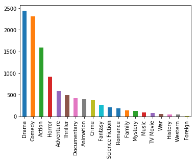

```python
# Separate the elements in the genre columns containing multiple values
df_m['genres']=df_m['genres'].str.split("|",expand=True)

# Get the count of different genres movies and display the visual
df_m['genres'].value_counts().plot(kind='bar');
```

From this visual above, we can see that *Drama, Comedy*, *Action*, *Horror* and *Adventure* movies are the top 5 genre. Now, let's explore more to get insight on which among these yields the highest profit.

```python
# styling plot

def graph_styling(xlabel = '', ylabel = '', title = ''):
    '''function for styling visualization'''

    plt.ylabel(ylabel)
    plt.xlabel(xlabel)
    plt.title(title)
    plt.show();
```

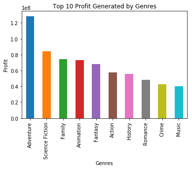

```python
# Display the top 10 genre that generated the higest profit

top_genres = df_m.groupby('genres')['profit'].mean().sort_values(ascending=False).head(10).plot(kind = 'bar')

# call the plot function while and pass, xlabel, label, and title repectively
graph_styling('Genres', 'Profit', 'Top 10 Profit Generated by Genres')
```

Cleary, even though drama movies appear most, adventure and science fiction movies generated the highest profit.

### Question 2: What characteristics are linked to the popularity of the movies?

Let check the relationship among various features to get insight on the features that are connected with the popularity.

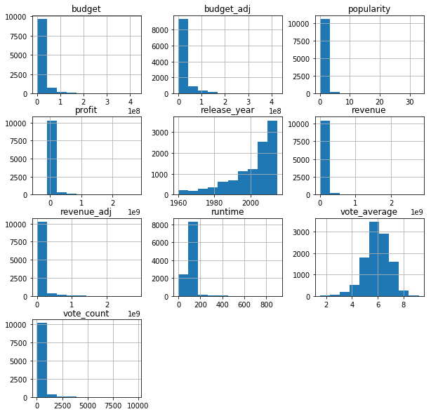

```python
# check the distribution of the numerical data

df_m.hist(figsize = (10,10));
```

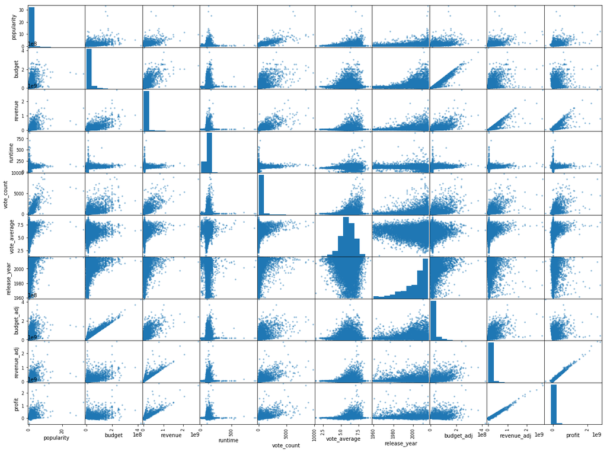

```python
# Check the correction for each feature

pd.plotting.scatter_matrix(df_m, figsize = (20,15));
```

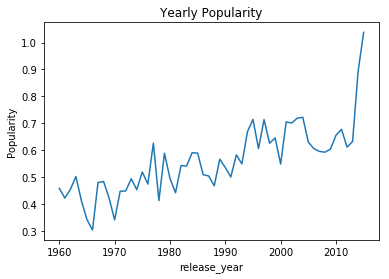

```python
# Check to see if the popularity is related to the release year.

year = df_m.groupby('release_year')['popularity'].mean()
year.plot(kind = 'line')

# call the plot function while and pass, xlabel, label, and title repectively

graph_styling('release_year', 'Popularity','Yearly Popularity' );
```

We can observe that the popularity of the films increased overtime and a high increase around 2010 upward. This could suggest that more films are being released yearly.

```python
# group the genre by popularity and budget

gen = df_m.groupby(['genres'], as_index=False)['popularity', 'budget'].mean()

gen.head()
```

|  | genres | popularity | budget |
| --- | --- | --- | --- |
| 0 | Action | 0.837782 | 3.078483e+07 |
| 1 | Adventure | 1.217868 | 4.577430e+07 |
| 2 | Animation | 0.817977 | 3.116989e+07 |
| 3 | Comedy | 0.538372 | 1.846931e+07 |
| 4 | Crime | 0.694063 | 1.939421e+07 |

[figure not shown]

```python
df_m.groupby(['genres'], as_index=False)['popularity', 'budget'].mean().plot(x='popularity', y='budget', kind ='scatter')

# call the plot function while and pass, xlabel, label, and title repectively
graph_styling('budget', 'popularity', 'Popularity vs Budget by Genres')
```

### Question 3: Which director is the most well-known and makes the most money from his films?

```python
# Separate the elements in the director columns containing multiple values
df_m['director']=df_m['director'].str.split("|",expand=True)

# put the directors in group according to their popularity and earning
director_df =df_m.groupby(['director'],as_index=False)['popularity', 'profit'].mean()
director_df.head()
```

|  | director | popularity | profit |
| --- | --- | --- | --- |
| 0 | Frédéric Jardin | 0.434506 | -2.420240e+06 |
| 1 | A. Todd Smith | 1.876037 | 2.519762e+07 |
| 2 | A.R. Murugadoss | 0.215030 | 6.775543e+07 |
| 3 | Aaron Aites | 0.108700 | 2.519762e+07 |
| 4 | Aaron Blaise | 1.653031 | -1.185350e+08 |

```python
# For the top 10, sort the directors by popularity.

top_director = director_df.sort_values(by=['popularity'], ascending = False).head(10)

top_director
```

|  | director | popularity | profit |
| --- | --- | --- | --- |
| 863 | Colin Trevorrow | 16.696886 | 6.287700e+08 |
| 2234 | Joe Russo | 12.971027 | 5.017796e+08 |
| 681 | Chad Stahelski | 11.422751 | 5.410479e+07 |
| 1240 | Don Hall | 8.691294 | 4.486685e+08 |
| 2541 | Juno John Lee | 8.411577 | 2.519762e+07 |
| 96 | Alan Taylor | 6.883129 | 2.763528e+08 |
| 3643 | Peter Richardson | 6.668990 | 2.519762e+07 |
| 811 | Christopher Nolan | 6.195521 | 3.199964e+08 |
| 128 | Alex Garland | 6.118847 | 2.011985e+07 |
| 3523 | Patrick Tatopoulos | 5.806897 | 5.725099e+07 |

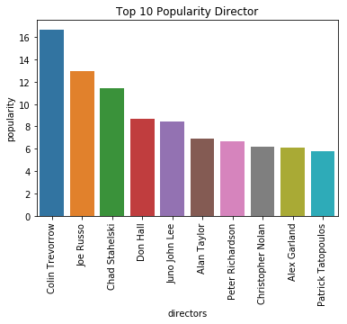

```python
# Display the visuals for the top 10 most popular directors

dir_viz= sn.barplot('director','popularity',data=top_director)
dir_viz.set_xticklabels(top_director['director'], rotation=90)

# call the plot function while and pass, xlabel, label, and title repectively

graph_styling('directors', 'popularity', 'Top 10 Popularity Director')
```

We can observe that Collin Trevorrow is the most popular director among the top 10 directors.

## Conclusions

### Limitations

> There are much too many zeros in both the budget and revenue columns. To replace these figures, we applied mean. This may not be the best solution. As a result, more research into how to deal with zero-valued properties is required.

```python
from subprocess import call
call(['python', '-m', 'nbconvert', 'Investigate_a_Movie_Dataset.ipynb'])
```

```
0
```